# Analysis of Crime within the District of Columbia

## Introduction

This data set contains information on 153687 felony arrests from the District of Columbia between the years 2013-2017. The information provided by this data set is readily available on the District of Columbia’s Police Department website. According to the dossier attached to this dataset, a felony arrest is defined as the police taking into custody a person that is suspected of having committed a crime. Although an arrest occurred, information about the conviction for the crime was not included. As a result, the modeling performed in this report has been done with the assumption that there is a 100% conviction rate for all arrests. This is unlikely to occur so some deviation from the model can be expected.

In this dataset, the crimes recorded here include boating violations, disorderly conduct, arson, homicide and many more. These crimes range in severity from felony convictions to misdemeanors. Of the crimes committed, 34133 were the result of the arrest of females, 119373 were males and 181 of unknown gender orientation. Because there are far more males present in this data set, the model built here may be more applicable to the male population. The mean age of those arrested was 34.8 years old.

For this report, we have sought to answer the question: **“Is it possible to accurately profile who is likely to commit a crime in DC?”** In the last few years, the use of racial profiling by law enforcement has been a controversial topic. Historically, police officers have had a large presence within primarily African American and Latino communities under the assumption that these areas are plagued with crime. As a result of this, there have many incidences of unlawful arrests and police brutality.

### Structure of the Data Set

```
## 'data.frame':    153687 obs. of  25 variables:
##  $ OBJECTID         : int  1 2 3 4 5 6 7 8 9 10 ...
##  $ YEAR             : int  2013 2013 2013 2013 2013 2013 2013 2013 2013 2013 ...
##  $ MONTH            : int  1 1 1 1 2 2 2 2 3 3 ...
##  $ DAY              : int  5 9 9 28 7 9 23 27 8 14 ...
##  $ HOUR             : int  11 15 17 10 7 4 18 6 15 9 ...
##  $ AGE              : int  34 23 44 23 22 50 30 23 27 27 ...
##  $ DEFENDANT_PSA    : int  0 403 0 505 103 0 602 505 603 607 ...
##  $ DEFENANT_ISTRICT : int  0 4 0 5 1 0 6 5 6 6 ...
##  $ Race             : Factor w/ 4 levels "1","2","3","4": 1 2 3 3 3 3 3 3 3 3 ...
##  $ ETHNICITY        : Factor w/ 2 levels "1","2": 1 1 1 1 1 1 NA 1 1 1 ...
##  $ SEX              : Factor w/ 3 levels "1","2","3": 1 2 2 2 2 2 2 2 3 2 ...
##  $ CATEGORY         : Factor w/ 29 levels "1","2","3","4",..: 2 6 22 11 22 1 1 1 6 2 ...
##  $ DESCRIPTION      : Factor w/ 997 levels "1","2","3","4",..: 664 816 737 910 737 883 904 904 751 429 ...
##  $ ARREST_PSA       : int  702 403 703 504 103 604 601 503 502 405 ...
##  $ ARREST_DISTRICT  : int  7 4 7 5 1 6 6 5 5 4 ...
##  $ ARREST_BLOCKX    : int  402600 398200 400700 400600 399000 406000 404200 402300 400000 400700 ...
##  $ ARREST_BLOCKY    : int  131700 143300 132800 139500 137300 135100 137500 138600 139300 142400 ...
##  $ OFFENSE_BLOCKY   : int  NA NA NA NA NA NA NA NA NA NA ...
##  $ OFFENSE_BLOCKX   : int  NA NA NA NA NA NA NA NA NA NA ...
##  $ OFFENSE_PSA      : int  NA NA 706 NA 101 NA NA NA NA NA ...
##  $ OFFENSE_DISTRICT : int  NA NA 7 NA 1 NA NA NA NA NA ...
##  $ ARREST_LATITUDE  : num  NA NA NA NA NA NA NA NA NA NA ...
##  $ ARREST_LONGITUDE : num  NA NA NA NA NA NA NA NA NA NA ...
##  $ OFFENSE_LATITUDE : num  NA NA NA NA NA NA NA NA NA NA ...
##  $ OFFENSE_LONGITUDE: num  NA NA NA NA NA NA NA NA NA NA ...
```

## Correlation of Age and Type of Crime

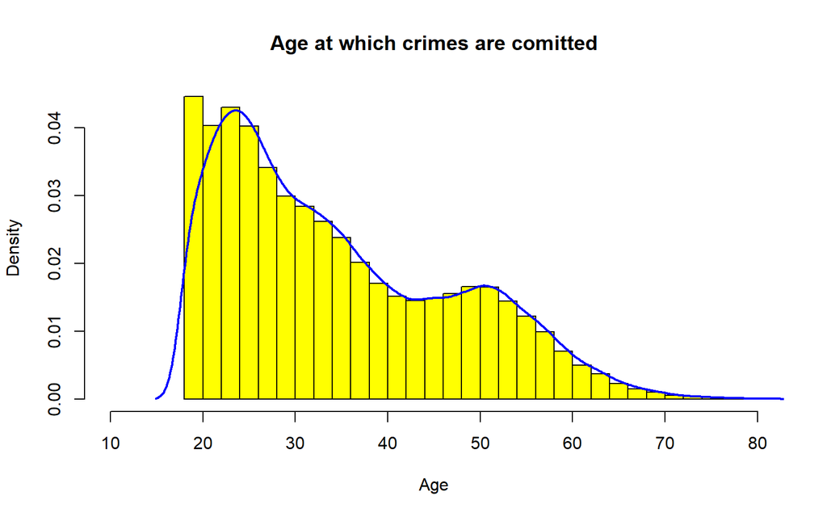

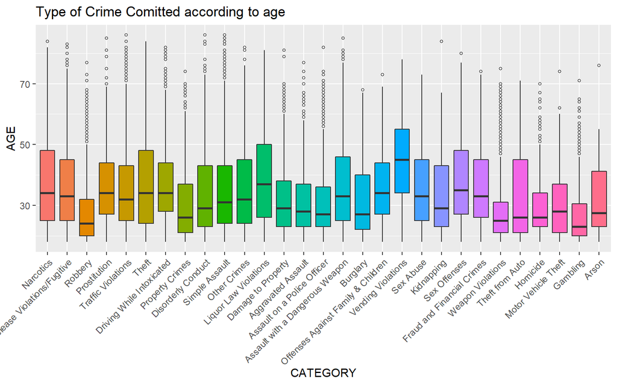

## Do people commit crimes in their own neighborhoods?

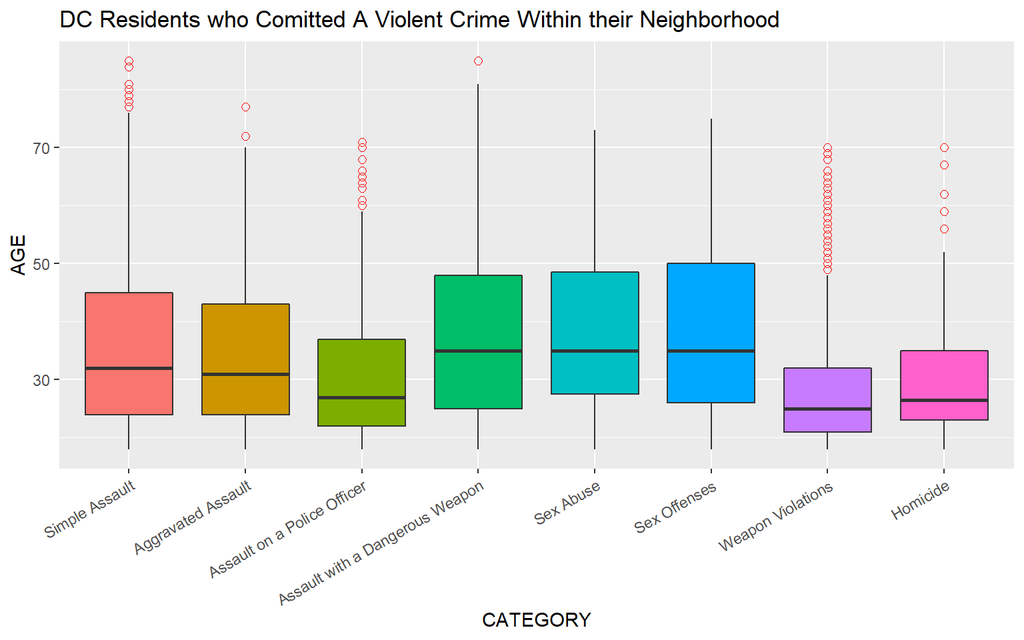

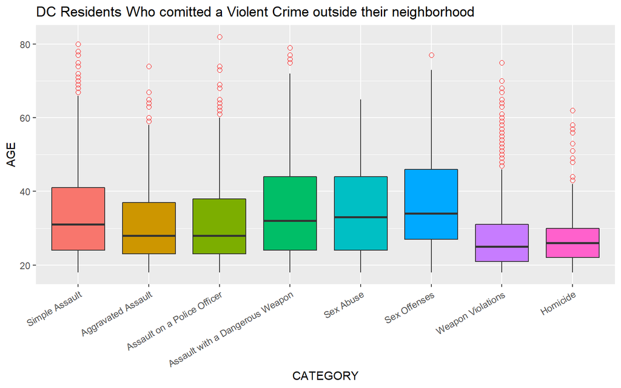

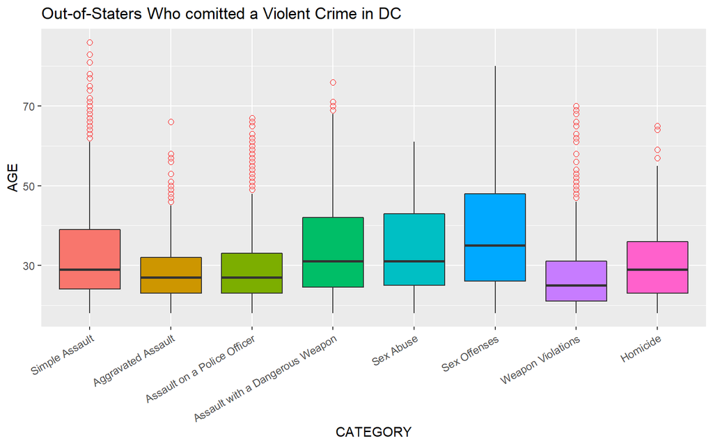

Interestingly, we found that 24.9% of the arrests made between 2013-2017 were of people who committed said crime within in their own neighborhood. Of this percentage, 51.3% of these crimes were the result of a violent crime. In comparison, 26.5% of the arrests documented here were made by people who lived outside DC or were out-of-staters, while the remaining portion was committed by DC residents who committed a crime in a different neighborhood. Of the crimes that out-of-staters were convicted of only 23.6% were violent. This could indicate that people are more likely to commit a violent crime within their own neighborhood. Similarly, the age spread for the violent crimes committed by those that live within DC in their own neighborhoods tended to be larger than for those who committed a crime in a different neighborhood.

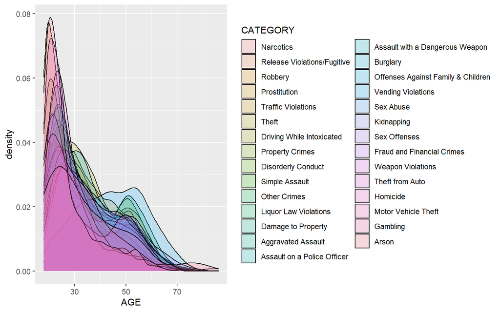

## Building a Multivariate Model

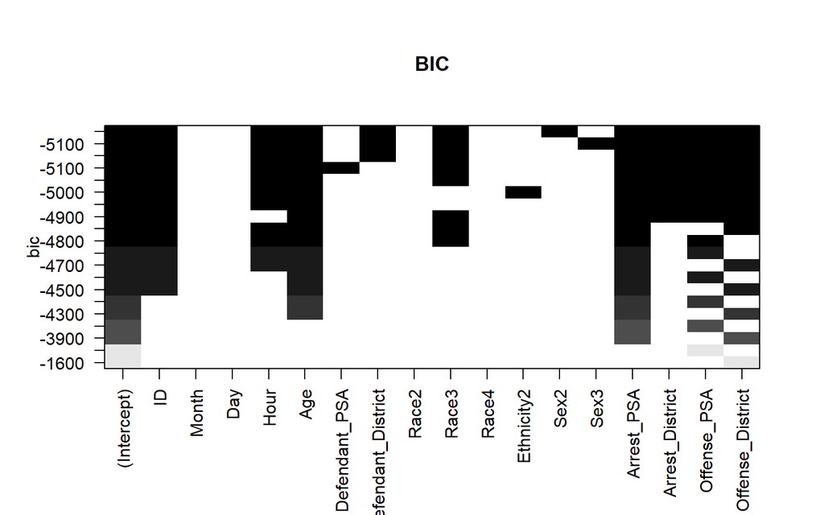

To develop a multivariate model, we have split the data set into a training and test set. The training data set contained 67% of the values, while the test set contained 33% of the values. Observations were separated randomly, and the data set was scaled to the center.

The multivariate model was produced using the `lda()` function from the MASS package. Linear discriminate analysis (LDA) seeks to find a linear combination of features that can be used to characterize two or more classes of an event. Essentially this model is attempting to recognize a pattern between the physical variables to predict the crime committed. The coefficients of linear discriminants of this model are displayed below. Each LD can be multiplied by the predictor variable to determine the score for that respondent, which can then be used to compute the posterior probability of class membership.

```
##                       LD1     LD2      LD3      LD4      LD5      LD6      LD7
## Hour             9.92e-01  2.0004 6.39e-01 6.77e-01 6.59e-01 9.86e-01 7.85e-01
## Age              1.20e+00  0.7034 5.82e-01 5.90e-01 1.63e+00 9.75e-01 1.34e+00
## Defendant_PSA    1.19e+00  1.2870 1.68e+00 6.65e-01 1.83e+00 1.03e+00 5.79e-01
## Race             1.23e+00  1.4889 1.34e+00 9.90e-01 9.39e-01 1.39e+00 2.31e+00
## Sex              9.88e-01  0.6062 1.36e+00 5.46e-01 5.70e-01 1.12e+00 9.62e-01
## Offense_PSA      1.32e-11  0.0171 1.46e-06 2.95e+02 1.40e+04 1.44e+37 1.65e-08
## Offense_District 2.66e+10 53.7871 6.29e+05 3.27e-03 7.50e-05 5.39e-38 7.95e+07
```

## Conclusion

Linear discriminate analysis assumes that the density of the data is gaussian and that all classes have covariance. This model has been shown to be well suited for multi-class analysis and similar to PCA it can be used as a dimensionality reduction technique. Despite this, when the amount of data for each arrest type is imbalanced in the training set, the model may be unable to accurately classify the observations in the test set. This is an accuracy problem that we will experience when using our model, because there are far less violent crimes in comparison to misdemeanors such as narcotics. Also, the LDA model requires a defined dimension. Higher-order interactions that may exist between the arrest types may therefore not be captured accurately by this model.

In conclusion, this data set has been found to have a wide variety of arrest types. Based on the findings in this report, we do not feel that the DC police are able to predict the profile of a person who is more likely to commit a crime in DC. There are two reasons why this is impossible. First, based on the BIC this model needs to include features such as the arrest district, and a person’s one police district. Often when police are profiling a potential criminal, they are making their arrests based on physical descriptions such as race and approximate age. As a result, our model would not actually be able to be employed by officers on the street. Similarly, in agreement with the literature “community policing” often involves some type of bias. To demonstrate the ability of a police officer to predict the crime a person may have committed the model would have to include some type of bias variable. Based on this current data set, community policing should not be used.